# Problem Set 06

Author

Leo Camino, ltc31

Published

2025-10-05

# Instructions

Answer the questions below using code blocks that generate the correct outputs. We encourage you to include explanatory text in your markdown document, however **each of your solutions should show how to generate the answer using R code**.

Write “robust” solutions wherever possible. A good rule of thumb for judging whether your solution is appropriately “robust” is to ask yourself “If I added additional observations or variables to this data set, or if the order of variables changed, would my code still compute the right solution?”

Make sure your markdown is nicely formatted – use headers, bullets, numbering, etc so that the structure of the document is clear.

Make sure to “Render” your document before submission to confirm that all code blocks and formatting is as you expect.

When completed, title your markdown file as follows (replace `XX` with the assignment number, e.g. `01`, `02`, etc):

- `netid_problemset_XX.qmd`

Submit both your markdown file and the generated HTML document via the Assignments submission section on Sakai.

# Problems

#### **1. Locate a graphic in a publication that you think does *not* represent graphical excellence. Provide the reference and figure number. Download or grab a screenshot of the graphic and insert it into your homework notebook. Explain what is not great about the graphic and what you think could be done better.**

[figure not shown]

This is *Figure 1* from the paper [*“Urban mixtures of non-essential trace metal elements affect the behaviour and stress levels of a passerine bird in a laboratory experiment”*](https://www.sciencedirect.com/science/article/pii/S0147651325009923) by Clément Parnet *et al.* (2025). I think this is a good example of a graph that obscures data. The first thing they do wrong is assuming statistical differences in these different treatments when they have such big error bars. The amount of outliers is a big alarm for me. The density of black dots screams heterogeneity. Either they have a few individuals behaving very differently (biologically interesting!) or there’s noise in measurement. Hiding that behind median comparisons weakens the data narrative. I would use instead violin plots to explore the nature of these data and being more sincere about the results. Secondly, I don’t really like the color palette. Even though this is subjective, I think they could have used a more inclusive color palette. Also, I think the legend occupies a big chunk of space, I would relocate it inside the borders of the graph, in the section where there’s space between purple and blue. Lastly, I think the way they show significant results through “a”, “b”, and “c”, is very inefficient for a graph with only four treatments. I would go for asterisks in this case. In summary, If I had to redo this graph, I would:

- Change boxplots for violin plots with individual datapoints (jittered)
- Use a subtle viridis palette instead of this high contrast one.
- Add the legend embedded in empty space.
- Compact layout with clear significance marks (asterisks) instead of letters.

#### 2. Using the `penguins` data from `palmerpenguins`, re-create the following plot with the included annotation elements:

[figure not shown]

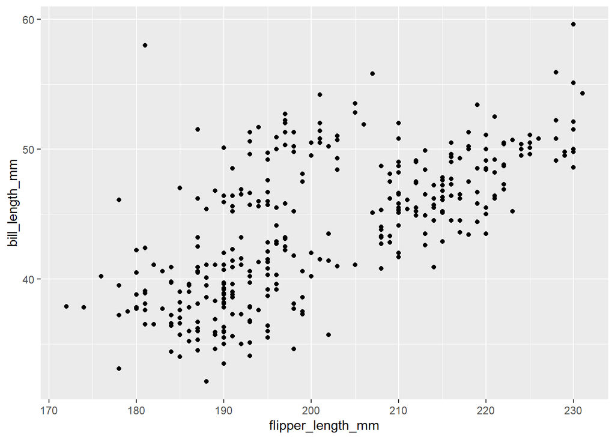

```r
library(palmerpenguins)
library(ggplot2)
library(dplyr)
penguins |>
  ggplot(aes(x = flipper_length_mm, y = bill_length_mm)) +
  geom_point()
```

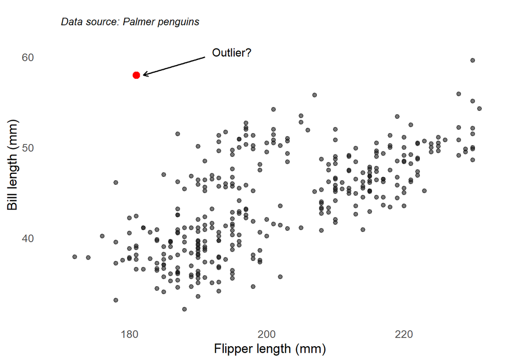

```r
outlier <- penguins %>%
  filter(bill_length_mm > 55 & flipper_length_mm < 185) |>
  slice(1)

ggplot(penguins, aes(x = flipper_length_mm, y = bill_length_mm)) +
  geom_point(color = "gray10", alpha = 0.6) +
  geom_point(data = outlier, aes(x = flipper_length_mm, y = bill_length_mm),
             color = "red", size = 3) +
  annotate("text", x = 192, y = 61.5, label = "Outlier?", hjust = 0, vjust = 1.5, size = 4) +
  annotate("segment", x = 191, xend = 182, y = 60, yend = 58,
           arrow = arrow(length = unit(0.2, "cm"))) +
  annotate("text", x = 170, y = 64, label = "Data source: Palmer penguins",
           hjust = 0, size = 3.5, fontface = "italic") +
  labs(
    x = "Flipper length (mm)",
    y = "Bill length (mm)"
  ) +
  theme_minimal(base_size = 13) +
  theme(panel.grid = element_blank())
```

#### 3. Using the data below, create a heatmap depicting covid deaths on average per 100K people, over time for US states. Filter out non-states (e.g. territories, protectorates) except for the District of Columbia.Make sure to use an appropriate color scale for the type of data depicted.

- nytimes-covid-data-us-states_2022-02.csv – Data on COVID cases and deaths, by state, from 2020 to 2022, compiled by the NY Times.

Your figure should look something like this:

[figure not shown]

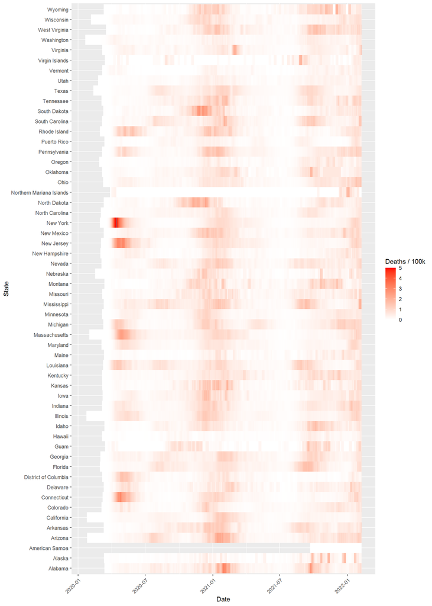

```r
library(tidyverse)
library(lubridate)

# Assuming your CSV is called 'covid_data.csv'
df <- read_csv("C:/Users/leoto/Desktop/nytimes-covid-data-us-states_2022-02.csv")
ggplot(df, aes(x = date, y = state, fill = deaths_avg_per_100k)) +
  geom_tile() +
  scale_fill_gradient(low = "white", high = "red", limits = c(0, 5)) +
  labs(x = "Date",
       y = "State",
       fill = "Deaths / 100k") +
  theme_gray() +
  theme(axis.text.x = element_text(angle = 45, hjust = 1))
```

## **Data lunch assignment**

Identify something that you learned from the presentation or discussion on Thursday that you found valuable. Provide a brief reflection here (1-5 sentences) and include code or pseudo-code if useful. Hint: if you have specific code examples, consider adding them to your notebook as well.

Last Lunch we discussed about how the Final Project of the course will work. We were asked to find a figure in the literature that we normally read to recreate it. It must be a complex - but not too complex- figure. This means, not a bar chart or scatter chart, but something more substantial such as the figures professor Paul Magwene presented as examples. Also, we were suggested to choose a figure that has several multiple parts. From the figures that were shown, I really liked the spectrophotometry results from professor Sönke Johnsen, however, I found his data very confusing and disorganized. I might go for that data set!